# esm206_lab6

Eli Schulman

11/1/2021

## Example of a rank-based test

We’ll make out own samples, using a pseudo random generator. - sample.int(range of numbers (20 = 0-20), size = number of samples, replace = TRUE is resampling) - set.seed() –> random sample will be same random sample for reproducability - set.seed() indicates the starting position in the long list of random int generated by R

```r
set.seed(1414)
gp_1 <- sample.int(20, size = 15, replace = TRUE)

set.seed(1424)
gp_2 <- sample.int(30, size = 15, replace = TRUE)
```

look for normality?

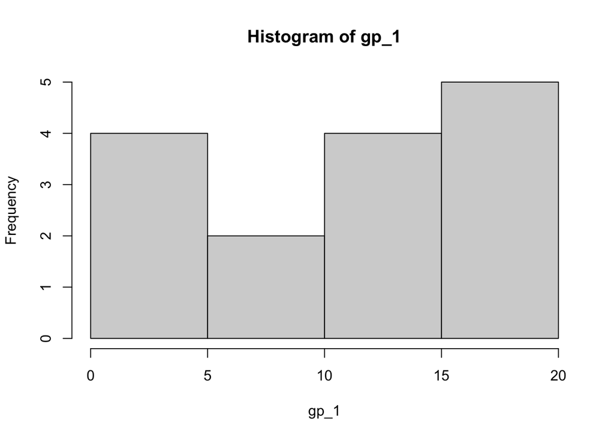

```r
hist(gp_1)
```

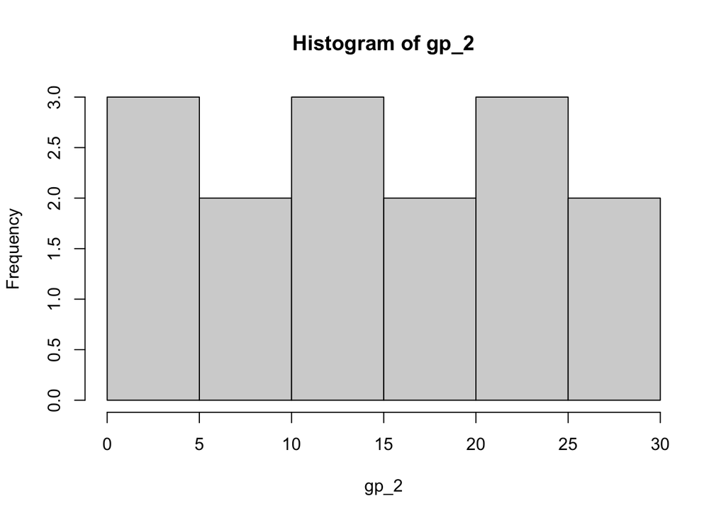

```r
hist(gp_2)
```

Try a t-test

```r
t.test(gp_1, gp_2)
```

```
##
##  Welch Two Sample t-test
##
## data:  gp_1 and gp_2
## t = -1.3241, df = 23.545, p-value = 0.1982
## alternative hypothesis: true difference in means is not equal to 0
## 95 percent confidence interval:
##  -9.558315  2.091648
## sample estimates:
## mean of x mean of y
##  11.40000  15.13333
```

p.val of .1982 –> if data is taken from pops with same mean, 19.82% of the time the means will be at least as different as our samples (15-11) –> this is possible, so the null holds that these populations might have the same mean.

Wilcox Test (Rank based test) - null hypothesis: if this samples were drawn for populations with the same ranks, the prob of finding samples with ranks at least as different as those found in our sample (.28)

```r
mwu <- wilcox.test(gp_1, gp_2)

mwu
```

```
##
##  Wilcoxon rank sum test with continuity correction
##
## data:  gp_1 and gp_2
## W = 86, p-value = 0.28
## alternative hypothesis: true location shift is not equal to 0
```

–> median scores for groups 1 and 2 did not differ significantly. (Mann Witney U test: U(df) = 86, p = .28)

## Linear Regression

simple linear regression (single dependent variable and single independent variable)

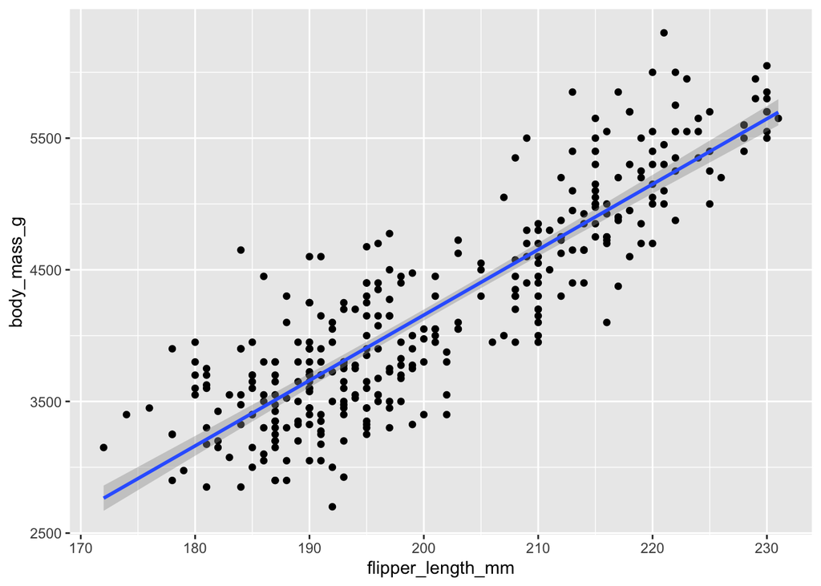

```r
#exploratory plot of penguin body mass (y) vs flipper length (x)
ggplot(penguins, aes(x = flipper_length_mm, y = body_mass_g)) +
  geom_point() +
  geom_smooth(method = lm) # This is wrong, didn;t see the line she added
```

Find a linear regression model using ordinary least squares describing the relationship etween flipper length and body mass for these penguins

3 pieces: - type of model? - what is the relationship to model (DV ~ IV(s)) - where is the data

```r
penguin_lm <- lm(body_mass_g ~ flipper_length_mm, data = penguins)
penguin_lm
```

```
##
## Call:
## lm(formula = body_mass_g ~ flipper_length_mm, data = penguins)
##
## Coefficients:
##       (Intercept)  flipper_length_mm
##          -5780.83              49.69
```

Regression line –> body_mass_g = 49.69(flipper_length_mm) - 5780.83

issue –> if you had a penguin with flipper length 0, the penguin would have a mass of -5780 g

### Broom package returns model outputs as tidy data pieces

```r
# broom:: not necessary to reference tidy() --> just did it to show its part of broom and not tidyverse
penguin_lm_tidy <- broom::tidy(penguin_lm)

penguin_lm_tidy
```

```
## # A tibble: 2 × 5
##   term              estimate std.error statistic   p.value
##   <chr>                <dbl>     <dbl>     <dbl>     <dbl>
## 1 (Intercept)        -5781.     306.       -18.9 5.59e- 55
## 2 flipper_length_mm     49.7      1.52      32.7 4.37e-107
```

How can I include my model equation in a report?

```r
penguin_reg <- extract_eq(model = penguin_lm, use_coefs = TRUE)

penguin_reg
```

$$\operatorname{\widehat{body\_mass\_g}} = -5780.83 + 49.69(\operatorname{flipper\_length\_mm})$$

Diagnostic plots that explore (regression fit?)

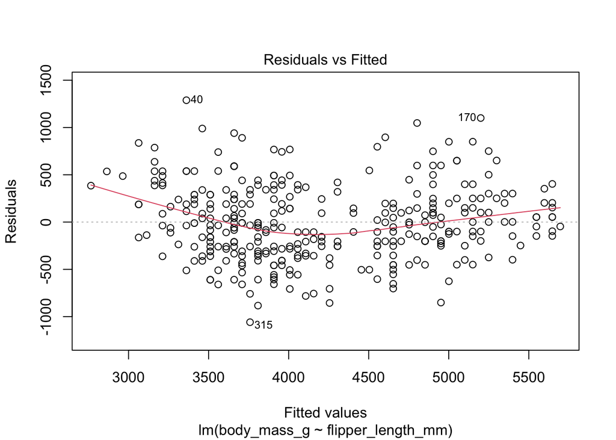

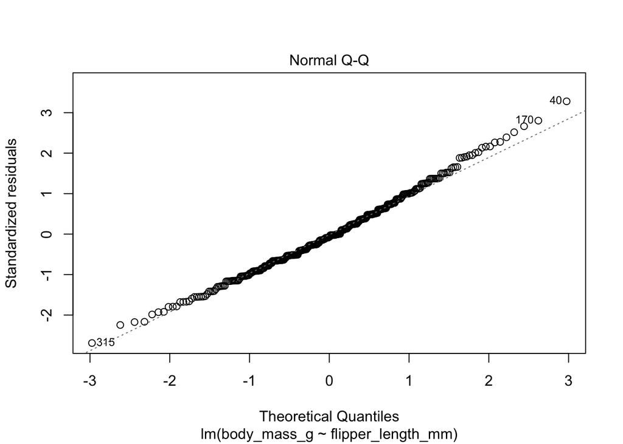

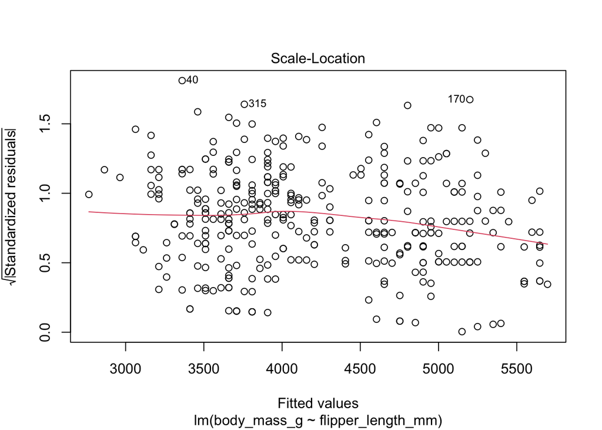

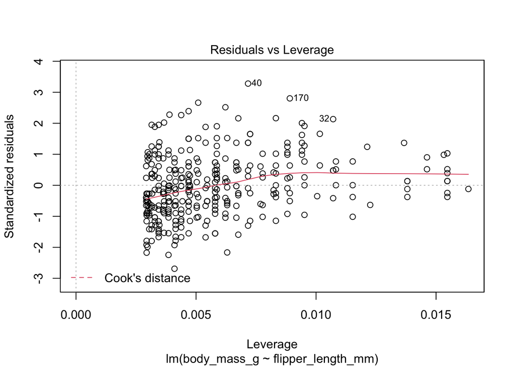

```r
plot(penguin_lm)
```

```r
# residual vs fitter:
# Q-Q:
# scale location:
# residual vs leverage:
```